# EDS 223: assignment 2

Gemma Del Rossi

2023-10-17

## Overview

Present-day environmental justice may reflect legacies of injustice in the past. The United States has a long history of racial segregation which is still visible. During the 1930’s the Home Owners’ Loan Corporation (HOLC), as part of the New Deal, rated neighborhoods based on their perceived safety for real estate investment. Their ranking system, (A (green), B (blue), C (yellow), D (red)) was then used to block access to loans for home ownership. Colloquially known as “redlining”, this practice has had widely-documented consequences not only for community wealth, but also health.[^1] Redlined neighborhoods have less greenery[^2] and are hotter than other neighborhoods.[^3]

Check out coverage by the [New York Times](https://www.nytimes.com/interactive/2020/08/24/climate/racism-redlining-cities-global-warming.html).

A recent study found that redlining has not only affected the environments communities are exposed to, it has also shaped our observations of biodiversity.[^4] Community or citizen science, whereby individuals share observations of species, is generating an enormous volume of data. Ellis-Soto and co-authors found that redlined neighborhoods remain the most undersampled areas across 195 US cities. This gap is highly concerning, because conservation decisions are made based on these data.

Check out coverage by EOS.

### Data

#### EJScreen

We will be working with data from the United States Environmental Protection Agency’s EJScreen: Environmental Justice Screening and Mapping Tool.

According to the [US EPA website](https://www.epa.gov/ejscreen/purposes-and-uses-ejscreen):

> This screening tool and data may be of interest to community residents or other stakeholders as they search for environmental or demographic information. It can also support a wide range of research and policy goals. The public has used EJScreen in many different locations and in many different ways.

> EPA is sharing EJScreen with the public:  
> - to be more transparent about how we consider environmental justice in our work,  
> - to assist our stakeholders in making informed decisions about pursuing environmental justice and,  
> - to create a common starting point between the agency and the public when looking at issues related to environmental justice.

EJScreen provides on environmental and demographic information for the US at the Census tract and [block group](https://en.wikipedia.org/wiki/Census_block_group) levels. You will be working with block group data that has been downloaded from the [EPA site](https://www.epa.gov/ejscreen/download-ejscreen-data). To understand the associated data columns, you will need to explore the Technical Documentation and column description spreadsheet available in the data folder. I also encourage you to explore the [limitations and caveats](https://www.epa.gov/ejscreen/limitations-and-caveats-using-ejscreen) of the data.

#### Mapping Inequality

A team of researchers, led by the [Digital Scholarship Lab](https://dsl.richmond.edu/) at the University of Richmond have digitized maps and information from the HOLC as part of the [Mapping Inequality](https://dsl.richmond.edu/panorama/redlining/#loc=5/39.1/-94.58) project.

We will be working with maps of HOLC grade designations for Los Angeles. Information on the data can be found [here](https://dsl.richmond.edu/panorama/redlining/#loc=5/39.1/-94.58&text=downloads).[^5]

#### Biodiversity observations

The Global Biodiversity Information Facility is the largest aggregator of biodiversity observations in the world. Observations typically include a location and date that a species was observed.

We will be working observations of birds from 2021 onward.

## Assignment

### Investigate the legacy of redlining in current environmental (in)justice

Load relevant packages.

```r
# set up WD

rm(list = ls())
getwd()
```

```
## [1] "C:/Users/gemma/Documents/EDS 223/Assignments/EDS223-assignment2"
```

```r
dir <- list()
dir$root <- paste0(dirname(getwd()),"/EDS223-assignment2")
dir$data <- paste0(dir$root,"/data") # if needed
lapply(dir, function(x) dir.create(x, showWarnings = F))
```

```
## $root
## [1] FALSE
##
## $data
## [1] FALSE
```

```r
# download necessary packages into library

if (!require("pacman")) install.packages("pacman")
pacman::p_load(
  tidyverse, tidylog, ggspatial, viridis, RColorBrewer, # geosphere, (not sure if needed)
  sf, terra, spData, spDataLarge, ggplot2, tmap)
```

Read in EJScreen data and filter to Los Angeles County (5 points)

```r
ejscreen <- st_read(paste0(dir$data,"/EJSCREEN_2023_BG_StatePct_with_AS_CNMI_GU_VI.gdb"))
#filter to LA county
LA_county <- ejscreen %>%
  filter(STATE_NAME == "California",
         CNTY_NAME == "Los Angeles County") %>%
  st_transform("EPSG:4326") # change CRS to work with lat/long coords easier for any cropping

st_crs(LA_county)
```

```
## Coordinate Reference System:
##   User input: EPSG:4326
##   wkt:
## GEOGCRS["WGS 84",
##     ENSEMBLE["World Geodetic System 1984 ensemble",
##         MEMBER["World Geodetic System 1984 (Transit)"],
##         MEMBER["World Geodetic System 1984 (G730)"],
##         MEMBER["World Geodetic System 1984 (G873)"],
##         MEMBER["World Geodetic System 1984 (G1150)"],
##         MEMBER["World Geodetic System 1984 (G1674)"],
##         MEMBER["World Geodetic System 1984 (G1762)"],
##         MEMBER["World Geodetic System 1984 (G2139)"],
##         ELLIPSOID["WGS 84",6378137,298.257223563,
##             LENGTHUNIT["metre",1]],
##         ENSEMBLEACCURACY[2.0]],
##     PRIMEM["Greenwich",0,
##         ANGLEUNIT["degree",0.0174532925199433]],
##     CS[ellipsoidal,2],
##         AXIS["geodetic latitude (Lat)",north,
##             ORDER[1],
##             ANGLEUNIT["degree",0.0174532925199433]],
##         AXIS["geodetic longitude (Lon)",east,
##             ORDER[2],
##             ANGLEUNIT["degree",0.0174532925199433]],
##     USAGE[
##         SCOPE["Horizontal component of 3D system."],
##         AREA["World."],
##         BBOX[-90,-180,90,180]],
##     ID["EPSG",4326]]
```

```r
st_bbox(LA_county) # woo
```

```
##       xmin       ymin       xmax       ymax
## -118.95173   32.75004 -117.64639   34.82331
```

Make a map of wastewater discharge by census block groups. Indicate which census block groups are above the 95th percentile of national values for wastewater discharge by adding a centroid. (10 points)

```r
# var name of wastewater discharge is PWDIS

summary(LA_county$PWDIS)
```

```
##      Min.   1st Qu.    Median      Mean   3rd Qu.      Max.      NA's
##   0.00000   0.00062   0.07061   1.87065   0.59644 189.77669        27
```

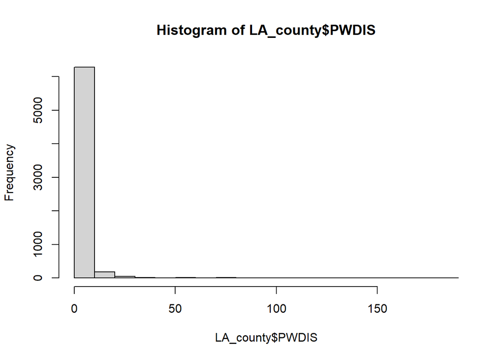

```r
hist(LA_county$PWDIS)
```

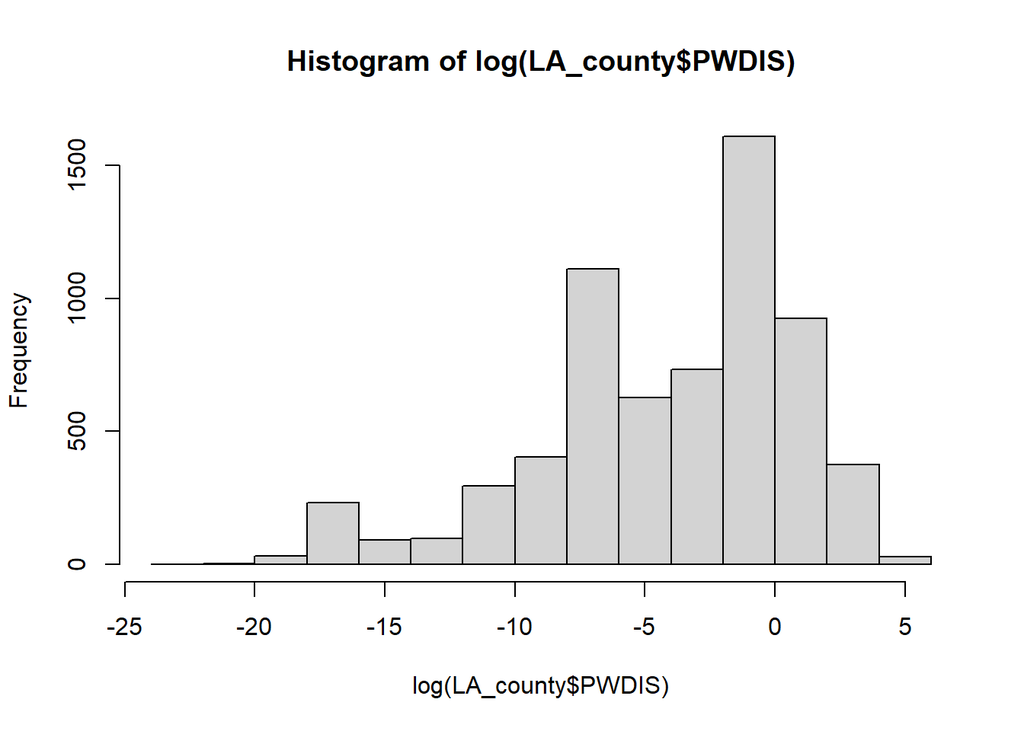

```r
hist(log(LA_county$PWDIS)) # logging the variable better for visualizing
```

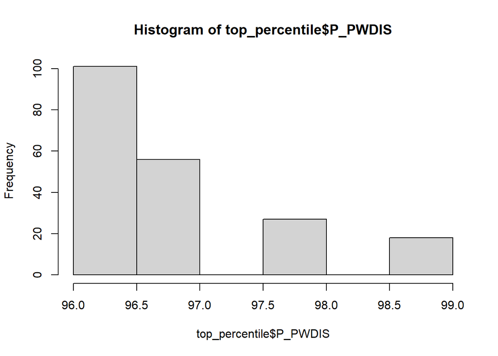

```r
# extract centroids of CBGs who are above the 95th percentile for waste water discharge
# Percentile var is P_PWDIS

top_percentile <- LA_county %>%
  filter(P_PWDIS > 95) %>%
  st_centroid()

  hist(top_percentile$P_PWDIS) # yep
```

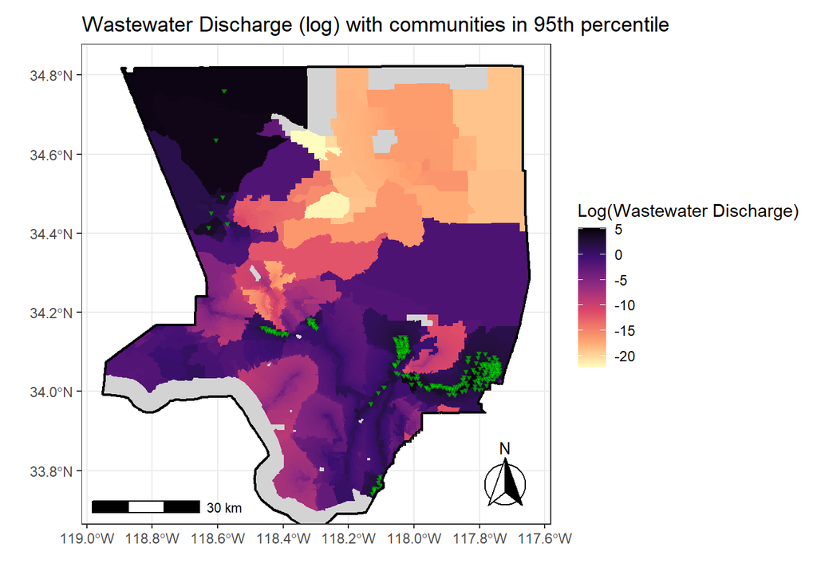

```r
# extract LA_county outline:

  LA_outline <- st_union(LA_county)

# map time

ggplot(LA_county) +
  geom_sf(aes(fill =log(PWDIS)),  col = NA) +
  geom_sf(fill = ifelse(is.na(LA_county$PWDIS), "lightgrey", NA),
          col = NA) + # fills in NA values
  geom_sf(data = top_percentile, fill = "green", col = "darkgreen",
          alpha = 0.5, cex = 0.75, pch = 25)+
  geom_sf(data= LA_outline, fill = NA, lwd = 0.8, col = "black")+
  coord_sf(ylim =c(33.72, 34.823)) + # cropped out Catalina islands
  scale_fill_viridis_c(option = "A", direction = -1, aesthetics = c("fill"))+
  labs(x = "",  y = "", title = "Wastewater Discharge (log) with communities in 95th percentile",
       fill = c("Log(Wastewater Discharge)"))+
  annotation_scale()+
  annotation_north_arrow(location = "br", style = north_arrow_fancy_orienteering())+
  theme_bw()
```

Find the percent of census block groups that have:  
- less than 5% of the population is considered low income (5 points)

```r
# variable for percentile that is low income : P_LOWINCPCT

wealthy <- LA_county %>%
  mutate(wealthy_cbgs = ifelse(LA_county$P_LOWINCPCT < 5, 1, 0)) %>%
  group_by(wealthy_cbgs) %>%
  summarise(count = n()) %>%
  st_drop_geometry()

# To get the percentage, we need to calculate:

pct_wealthy <- (wealthy[2,2]/nrow(st_drop_geometry(LA_county))*100)

pct_wealthy
```

```
##      count
## 1 3.201335
```

Of the CBGs that fall within LA county, only approximately 3.2% of them have less than 5% of the population being considered low income.

Find the percent of census block groups that are:  
- above the 80th percentile for Particulate Matter 2.5 AND  
- above the 80th percentile for Superfund proximity (10 points)

```r
pm25_sf <- LA_county %>%
  filter(P_PM25 > 80,
         P_PNPL > 80) %>%
  group_by(ST_ABBREV) %>%
  summarise(count = n()) %>%
  st_drop_geometry()

# to find the percentage, we need to calculate:

pct_pm25_sf <-(pm25_sf[1,2]/nrow(st_drop_geometry(LA_county)))*100

pct_pm25_sf
```

```
##    count
## 1 17.357
```

Import redlining information for Los Angeles.

```r
LA_redlining <- st_read("https://dsl.richmond.edu/panorama/redlining/static/downloads/geojson/CALosAngeles1939.geojson") %>%
  st_make_valid()
```

Make a map of historical redlining boundaries, colored by HOLC grade. (5 points)

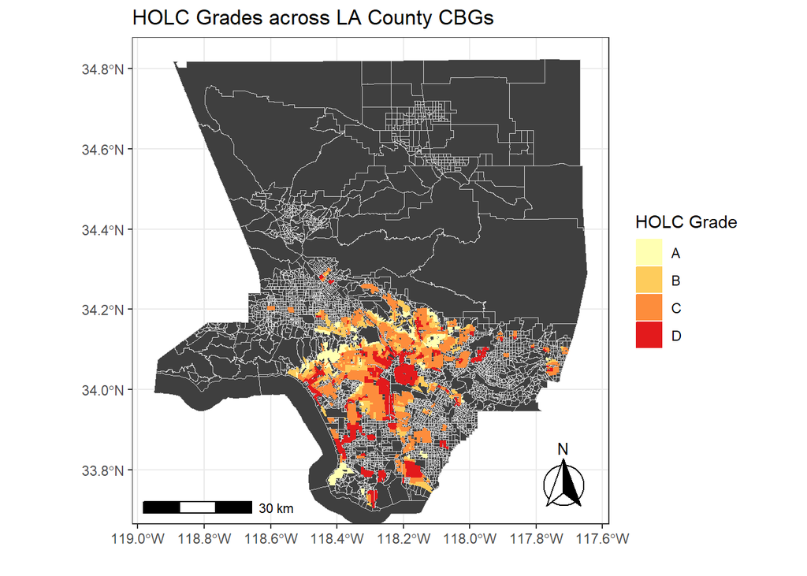

```r
# add colors for scale
colors <- brewer.pal(4, "YlOrRd")
gray_palette <- colorRampPalette(c("white", "black"))(5)


# map time

ggplot() +
  geom_sf(data = LA_county, fill = gray_palette[4], col = "lightgrey")+
  geom_sf(data = LA_redlining, aes(fill = holc_grade, col = holc_grade)) +
  scale_color_discrete(type = colors, aesthetics = c("fill", "col")) +
  coord_sf(ylim =c(33.72, 34.823)) +  # cropped out Catalina islands
  labs(x="", y = "",
       title = "HOLC Grades across LA County CBGs",
       fill = "HOLC Grade", col = "HOLC Grade")+
  annotation_scale()+
  annotation_north_arrow(location = "br", style = north_arrow_fancy_orienteering())+
  theme_bw()
```

Find the number of census block groups that fall within areas with HOLC grades hint: make sure the CRS match (15 points)

```r
st_crs(LA_redlining)

st_crs(LA_county) # they match since I adjusted it in the beginning

cbgs_holc <- LA_redlining %>%
  st_filter(y = LA_county, .predicate = st_intersects)

nrow(st_drop_geometry(cbgs_holc))
```

[output not shown]

There are 416 CBGs that fall within the HOLC grades.

Summarize current conditions based on EJScreen data within historical redlining categories using the mean of the following variables:  
-% low income.  
- percentile for particulate Matter 2.5.  
- percentile for low life expectancy.  
- percentile for air toxics cancer risk (20 points)

```r
# want to join the Redlining dataset with the LA_county dataset

holc_ej <- st_join(LA_redlining, LA_county, left = TRUE)

holc_ej_stats <- holc_ej %>%
  group_by(holc_grade) %>%
  summarise(mean_p_lowinc = mean(P_LOWINCPCT, na.rm = TRUE),
            mean_p_pm25 = mean(P_PM25, na.rm = TRUE),
            mean_p_llife = mean(P_LIFEEXPPCT, na.rm = TRUE),
            mean_p_cancer = mean(P_CANCER, na.rm = TRUE)) %>%
  st_drop_geometry()

holc_ej_stats
```

```
## # A tibble: 4 × 5
##   holc_grade mean_p_lowinc mean_p_pm25 mean_p_llife mean_p_cancer
## * <chr>              <dbl>       <dbl>        <dbl>         <dbl>
## 1 A                   29.9        72.1         23.7          44.0
## 2 B                   44.7        76.3         37.4          47.7
## 3 C                   59.4        78.8         47.9          54.6
## 4 D                   65.6        80.2         53.1          56.5
```

Please write 2-3 sentences reflecting on these results. (5 points)

We can see from these results that HOLC grade assigned to CBGs does associate with higher environmental injustices. For example, the mean percentage low income within census blocks increases as we go down the HOLC grade, as well as exposure to PM 2.5. It seems like the lower the HOLC grade (which most likely corresponds to the % POC as well), the more environmental risks and harms are present which confirms the narrative of redlining.

### Investigate the legacy of redlining in biodiversity observations

For bird observations from 2022 that fall within neighborhoods with HOLC grads, find the percent of observations within each redlining categories and plot results. hint: make sure that the bird observations have the same CRS as redlining data. (20 points)

```r
# download bird data

birds <- st_read(paste0(dir$data, "/gbif-birds-LA"))
#check matching CRSs

if (st_crs(birds) == st_crs(LA_redlining)){
  print("The CRS's match")
} else {
  print("The CRS's do not match, you need to transform 1 to match the other")
}
```

```
## [1] "The CRS's match"
```

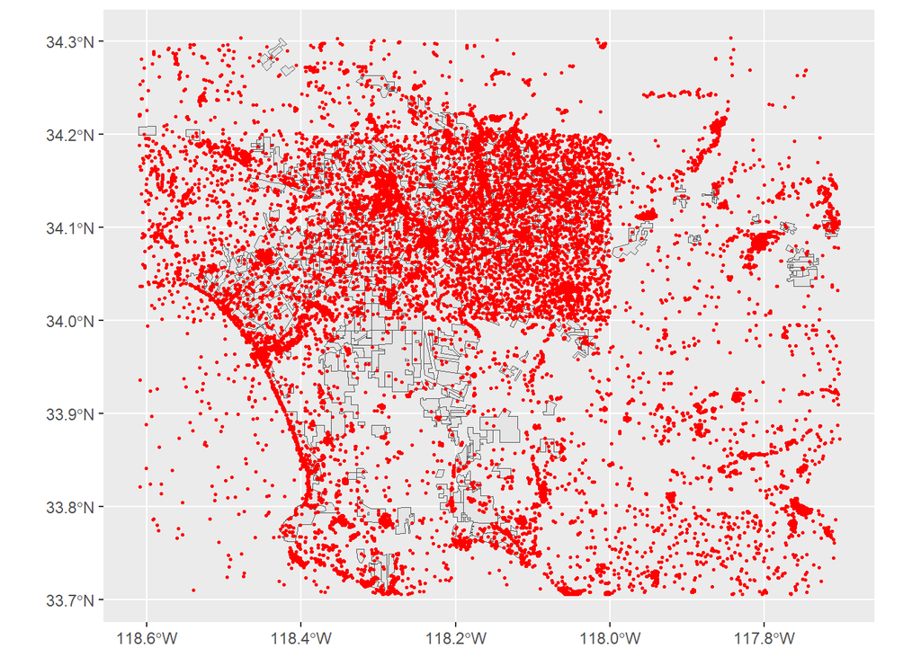

```r
# filter to those within the year 2022 and see where they match

birds_2022 <- birds %>%
  filter(year == 2022)

ggplot(LA_redlining) +
  geom_sf() +
  geom_sf(data = birds_2022, col = "red", cex = 0.5)
```

```r
# Crop to only include birds within HOLC CBGs by count

LA_redlining$bird_count <- lengths(st_intersects(LA_redlining, birds_2022))

# create summary statistic where each HOLC has percentage of total birds observed in 2022

birds_by_holc <- LA_redlining %>%
  group_by(holc_grade) %>%
  summarise(holc_birds_pct = (sum(bird_count, na.rm=TRUE)/nrow(birds_2022))*100) %>%
  st_drop_geometry()

birds_by_holc
```

```
## # A tibble: 4 × 2
##   holc_grade holc_birds_pct
## * <chr>               <dbl>
## 1 A                    2.40
## 2 B                    2.97
## 3 C                    5.47
## 4 D                    4.48
```

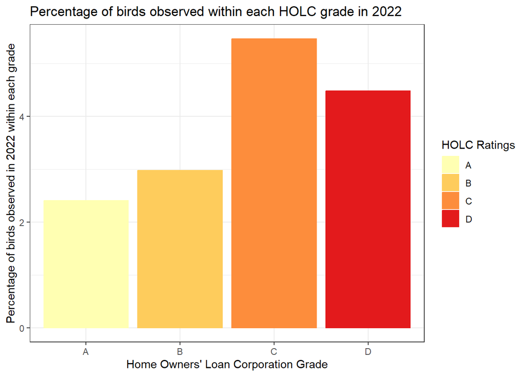

```r
# visualization

ggplot(birds_by_holc) +
  geom_col(aes(x = holc_grade, y = holc_birds_pct, fill = holc_grade, col = holc_grade)) +
  scale_color_discrete(type = colors, aesthetics = c("fill", "col")) +
  labs(x = "Home Owners' Loan Corporation Grade",
       y = "Percentage of birds observed in 2022 within each grade",
       title = "Percentage of birds observed within each HOLC grade in 2022",
       fill = "HOLC Ratings", col = "HOLC Ratings") +
  theme_bw()
```

Please write 2-3 sentences reflecting on these results. Are they surprising? If so, why? What are some potential implications? (5 points)

My results suggest that lower HOLC grades actually have more observed birds, which I found surprising. I would have expected to see low bird densities in neighborhoods that receive lower grades (i.e. more discriminated against) due to environmental justice factors such as poorer/minority neighborhoods typically having less trees and green space. However, this shows the opposite! I wonder if it’s due to the type of bird we’re observing in the data? Like a flock of seagulls or other “common” city birds are prevalent in these areas more so than others (e.g. Anna’s hummingbird, which is by my apartment all the time)?

The implications of this suggest that there might be greater benefits reforesting/providing more green space (or in the case of LA, xero-scaping?) in these neighborhoods, given there are higher densities of birds. It’s a win-win solution for the birds and people who also could benefit from more public amenities.

[^1]: Gee, G. C. (2008). A multilevel analysis of the relationship between institutional and individual racial discrimination and health status. American journal of public health, 98(Supplement_1), S48-S56.
[^2]: Nardone, A., Rudolph, K. E., Morello-Frosch, R., & Casey, J. A. (2021). Redlines and greenspace: the relationship between historical redlining and 2010 greenspace across the United States. Environmental health perspectives, 129(1), 017006.
[^3]: Hoffman, J. S., Shandas, V., & Pendleton, N. (2020). The effects of historical housing policies on resident exposure to intra-urban heat: a study of 108 US urban areas. Climate, 8(1), 12.
[^4]: Ellis-Soto, D., Chapman, M., & Locke, D. H. (2023). Historical redlining is associated with increasing geographical disparities in bird biodiversity sampling in the United States. Nature Human Behaviour, 1-9.
[^5]: Robert K. Nelson, LaDale Winling, Richard Marciano, Nathan Connolly, et al., “Mapping Inequality,” American Panorama, ed. Robert K. Nelson and Edward L. Ayers, accessed October 17, 2023, https://dsl.richmond.edu/panorama/redlining/